# Homework Week 12

Annanina Koster

5 januari 2016

The homework [7 | 2016]

The data sleepstudy (lme4) allow to measure the effect of sleep deprivation of reaction time.

The average reaction time per day for subjects in a sleep deprivation study. On day 0 the subjects had their normal amount of sleep. Starting that night they were restricted to 3 hours of sleep per night. The observations represent the average reaction time on a series of tests given each day to each subject.

With the use of the sleepstudy:

- Plot the relation between Reaction and Days for each subject independently.
- Build a model with random coefficients for linear trend between Reaction and Days.
- Extract individual slopes for the relation from the model with random effects. Present summary statistics of these slopes (1Q, median, 3Q).

First, the data should be loaded and inspected. There are 180 observations. All persons have been observed 10 times, one time every day for 10 days (0-9). Their mean reaction was 298.5.

```r
library(lme4)
library(lattice)
summary(sleepstudy)
```

```
##     Reaction          Days        Subject
##  Min.   :194.3   Min.   :0.0   308    : 10
##  1st Qu.:255.4   1st Qu.:2.0   309    : 10
##  Median :288.7   Median :4.5   310    : 10
##  Mean   :298.5   Mean   :4.5   330    : 10
##  3rd Qu.:336.8   3rd Qu.:7.0   331    : 10
##  Max.   :466.4   Max.   :9.0   332    : 10
##                                (Other):120
```

```r
dat <- sleepstudy
table(dat$Subject)
```

```
##
## 308 309 310 330 331 332 333 334 335 337 349 350 351 352 369 370 371 372
##  10  10  10  10  10  10  10  10  10  10  10  10  10  10  10  10  10  10
```

For each Subject, the relation between Reaction and Days looks as follows:

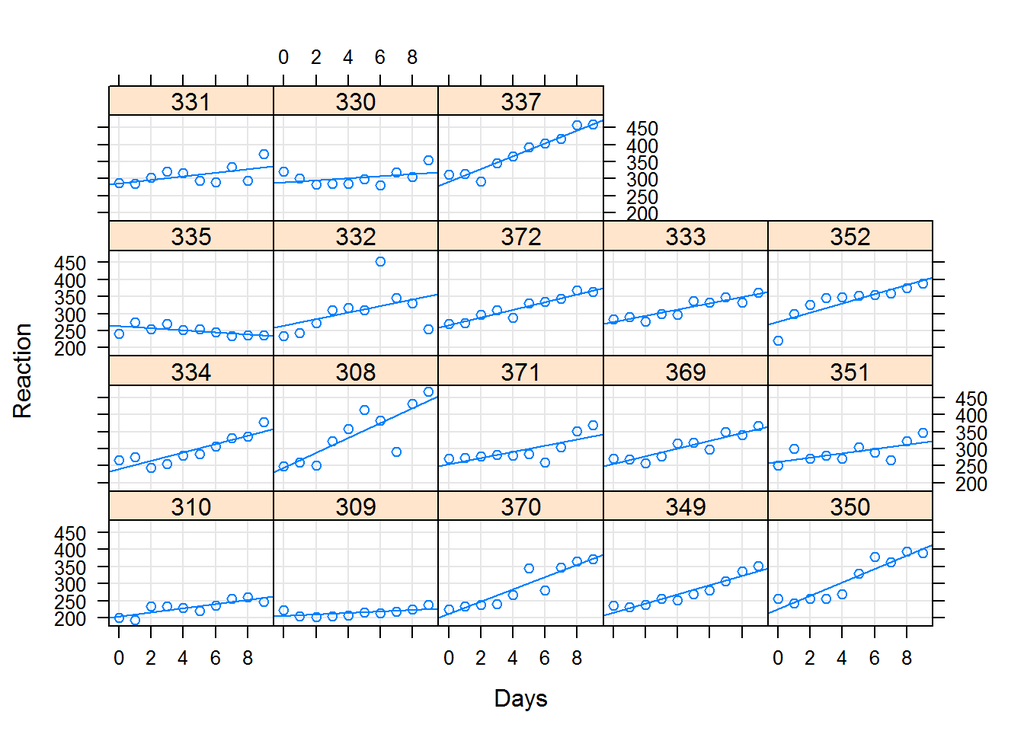

```r
xyplot(Reaction ~ Days | Subject, dat, type = c("g","p","r"), index = function(x,y) coef(lm(y ~ x))[1])
```

I believe that the most suitable model for this dataset would have the variable Days as a fixed effect, because we want to know the effect of the number of days without sleep. Moreover, we would like to distinguish the data per subject. As can be seen in the plots below, log(Reaction) does not make a lot of difference for the normality of the model. It also shows from the ANOVA test.

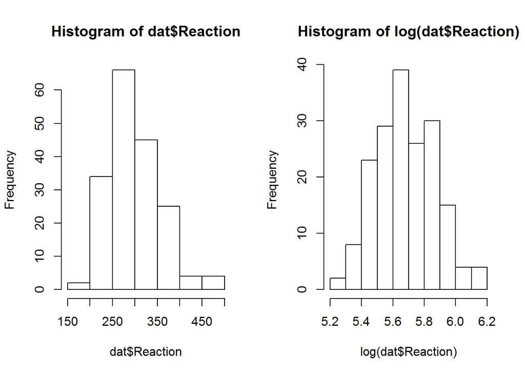

```r
par(mfrow=c(1,2))
hist(dat$Reaction)
hist(log(dat$Reaction))
```

```r
mdl0 <- lmer(log(Reaction) ~ Days + (1|Subject), data=dat)

mdl1 <- lmer(Reaction ~ 1 + (1|Subject), data=dat) #model with slope only
summary(mdl1)
```

```
## Linear mixed model fit by REML ['lmerMod']
## Formula: Reaction ~ 1 + (1 | Subject)
##    Data: dat
##
## REML criterion at convergence: 1904.3
##
## Scaled residuals:
##     Min      1Q  Median      3Q     Max
## -2.4983 -0.5501 -0.1476  0.5123  3.3446
##
## Random effects:
##  Groups   Name        Variance Std.Dev.
##  Subject  (Intercept) 1278     35.75
##  Residual             1959     44.26
## Number of obs: 180, groups:  Subject, 18
##
## Fixed effects:
##             Estimate Std. Error t value
## (Intercept)   298.51       9.05   32.98
```

```r
#here we can see a very high intercept and large differences between subjects
#moreover, we want to know the linear effect of days, so I include it in the second model

mdl2 <- lmer(Reaction ~ Days + (1|Subject), data=dat)
summary(mdl2)
```

```
## Linear mixed model fit by REML ['lmerMod']
## Formula: Reaction ~ Days + (1 | Subject)
##    Data: dat
##
## REML criterion at convergence: 1786.5
##
## Scaled residuals:
##     Min      1Q  Median      3Q     Max
## -3.2257 -0.5529  0.0109  0.5188  4.2506
##
## Random effects:
##  Groups   Name        Variance Std.Dev.
##  Subject  (Intercept) 1378.2   37.12
##  Residual              960.5   30.99
## Number of obs: 180, groups:  Subject, 18
##
## Fixed effects:
##             Estimate Std. Error t value
## (Intercept) 251.4051     9.7467   25.79
## Days         10.4673     0.8042   13.02
##
## Correlation of Fixed Effects:
##      (Intr)
## Days -0.371
```

```r
#here we see a much lower intercept, fewer differences between subjects and a slope of 10 for days

anova(mdl0, mdl2)
```

```
## refitting model(s) with ML (instead of REML)
```

```
## Data: dat
## Models:
## mdl0: log(Reaction) ~ Days + (1 | Subject)
## mdl2: Reaction ~ Days + (1 | Subject)
##      Df     AIC     BIC  logLik deviance Chisq Chi Df Pr(>Chisq)
## mdl0  4 -270.19 -257.42  139.09  -278.19
## mdl2  4 1802.08 1814.85 -897.04  1794.08     0      0          1
```

```r
#it can be seen that the use of log(Reaction) does not improve the model significantly, hence I will not

anova(mdl1, mdl2)
```

```
## refitting model(s) with ML (instead of REML)
```

```
## Data: dat
## Models:
## mdl1: Reaction ~ 1 + (1 | Subject)
## mdl2: Reaction ~ Days + (1 | Subject)
##      Df    AIC    BIC  logLik deviance  Chisq Chi Df Pr(>Chisq)
## mdl1  3 1916.5 1926.1 -955.27   1910.5
## mdl2  4 1802.1 1814.8 -897.04   1794.1 116.46      1  < 2.2e-16 ***
## ---
## Signif. codes:  0 '***' 0.001 '**' 0.01 '*' 0.05 '.' 0.1 ' ' 1
```

```r
#it is shown that the second model is significantly better than the first (for a low p-value always choose the model with the highest degrees of freedom)

mdl3 <- lmer(Reaction ~ Days + (Days|Subject), data=dat)
summary(mdl3)
```

```
## Linear mixed model fit by REML ['lmerMod']
## Formula: Reaction ~ Days + (Days | Subject)
##    Data: dat
##
## REML criterion at convergence: 1743.6
##
## Scaled residuals:
##     Min      1Q  Median      3Q     Max
## -3.9536 -0.4634  0.0231  0.4634  5.1793
##
## Random effects:
##  Groups   Name        Variance Std.Dev. Corr
##  Subject  (Intercept) 612.09   24.740
##           Days         35.07    5.922   0.07
##  Residual             654.94   25.592
## Number of obs: 180, groups:  Subject, 18
##
## Fixed effects:
##             Estimate Std. Error t value
## (Intercept)  251.405      6.825   36.84
## Days          10.467      1.546    6.77
##
## Correlation of Fixed Effects:
##      (Intr)
## Days -0.138
```

```r
#in this model we also see that the slope of Days may differ per Subject
#this model is expected to be even better

anova(mdl2, mdl3)
```

```
## refitting model(s) with ML (instead of REML)
```

```
## Data: dat
## Models:
## mdl2: Reaction ~ Days + (1 | Subject)
## mdl3: Reaction ~ Days + (Days | Subject)
##      Df    AIC    BIC  logLik deviance  Chisq Chi Df Pr(>Chisq)
## mdl2  4 1802.1 1814.8 -897.04   1794.1
## mdl3  6 1763.9 1783.1 -875.97   1751.9 42.139      2  7.072e-10 ***
## ---
## Signif. codes:  0 '***' 0.001 '**' 0.01 '*' 0.05 '.' 0.1 ' ' 1
```

```r
#model 3 is preferred over model 2!

mdl4 <- lmer(Reaction ~ Days + (Days-1|Subject) + (1|Subject), data=dat)
summary(mdl4)
```

```
## Linear mixed model fit by REML ['lmerMod']
## Formula: Reaction ~ Days + (Days - 1 | Subject) + (1 | Subject)
##    Data: dat
##
## REML criterion at convergence: 1743.7
##
## Scaled residuals:
##     Min      1Q  Median      3Q     Max
## -3.9626 -0.4625  0.0204  0.4653  5.1860
##
## Random effects:
##  Groups    Name        Variance Std.Dev.
##  Subject   Days         35.86    5.988
##  Subject.1 (Intercept) 627.57   25.051
##  Residual              653.58   25.565
## Number of obs: 180, groups:  Subject, 18
##
## Fixed effects:
##             Estimate Std. Error t value
## (Intercept)  251.405      6.885   36.51
## Days          10.467      1.560    6.71
##
## Correlation of Fixed Effects:
##      (Intr)
## Days -0.184
```

```r
anova(mdl3, mdl4)
```

```
## refitting model(s) with ML (instead of REML)
```

```
## Data: dat
## Models:
## mdl4: Reaction ~ Days + (Days - 1 | Subject) + (1 | Subject)
## mdl3: Reaction ~ Days + (Days | Subject)
##      Df    AIC    BIC  logLik deviance  Chisq Chi Df Pr(>Chisq)
## mdl4  5 1762.0 1778.0 -876.00   1752.0
## mdl3  6 1763.9 1783.1 -875.97   1751.9 0.0639      1     0.8004
```

```r
#it is found that model 3 is the most preferred model!
```

In order to extract the slopes of this relation per Subject:

```r
fixef(mdl3)
```

```
## (Intercept)        Days
##   251.40510    10.46729
```

```r
head(ranef(mdl3)$Subject)
```

```
##     (Intercept)       Days
## 308    2.258565  9.1989719
## 309  -40.398577 -8.6197032
## 310  -38.960246 -5.4488799
## 330   23.690498 -4.8143313
## 331   22.260203 -3.0698946
## 332    9.039526 -0.2721707
```

```r
randomCoefs = t(t(ranef(mdl3)$Subject) + fixef(mdl3))
randomCoefs
```

```
##     (Intercept)       Days
## 308    253.6637 19.6662579
## 309    211.0065  1.8475828
## 310    212.4449  5.0184060
## 330    275.0956  5.6529547
## 331    273.6653  7.3973914
## 332    260.4446 10.1951153
## 333    268.2455 10.2436615
## 334    244.1725 11.5418620
## 335    251.0714 -0.2848732
## 337    286.2955 19.0955699
## 349    226.1950 11.6407002
## 350    238.3351 17.0814910
## 351    255.9829  7.4520288
## 352    272.2687 14.0032993
## 369    254.6806 11.3395026
## 370    225.7922 15.2897506
## 371    252.2121  9.4791309
## 372    263.7196 11.7513157
```

```r
#but we need just the slopes, so:
slopes <- ranef(mdl3)$Subject[,2] + fixef(mdl3)[2]
slopes
```

```
##  [1] 19.6662579  1.8475828  5.0184060  5.6529547  7.3973914 10.1951153
##  [7] 10.2436615 11.5418620 -0.2848732 19.0955699 11.6407002 17.0814910
## [13]  7.4520288 14.0032993 11.3395026 15.2897506  9.4791309 11.7513157
```

```r
summary(slopes)
```

```
##    Min. 1st Qu.  Median    Mean 3rd Qu.    Max.
## -0.2849  7.4110 10.7900 10.4700 13.4400 19.6700
```

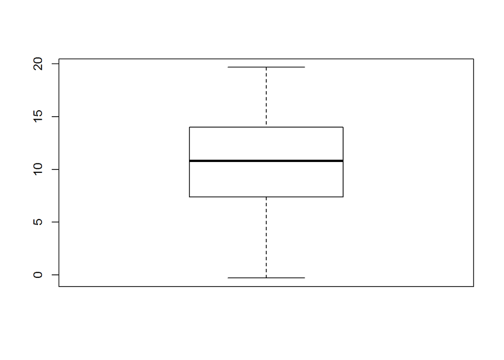

```r
boxplot(slopes) #to visualize
```

In conclusion, almost all subjects got a slower reaction as they got less sleep, which is what we expected since it makes sense!